# Week 05

Central Limit Theorem

Dr. Peng Zhao

2020-10-14

## Ice breaking

- Role play: *The Manga Guide to Statistics*: Standard Score
- Keywords: standard score $z_\mathrm{score} = \frac{x - \mu}{\sigma}$, deviation score $z_d = 10z + 50$

## Q & A

Q1. When should I use the population standard deviation $\sigma$ and when sample standard deviation $s$?

A1. It depends how you understand your data and what your purpose is. When you want to describe the characteristics of your data itself, you treat your data as a population. When you want to make an estimate of the population from your data as a subset of the population, you treat your data as a sample.

Q2. I cannot install the GUIs of R.

A2. Use other GUIs, or don’t use GUIs.

- https://hiplot.com.cn/?lang=en

Q3. I don’t understand the argument `margin` in the R function `apply()`. Could you explain more? Could you teach more R than statistics?

A3. In principle, no. But I will try explain more about the R functions we use in class.

## Objectives

1. Understand the sampling distribution
2. Understand the Central Limit Theorem (CLT)
3. Apply the CLT in environmental science

## Revisit the $z$ distribution

What is the standard normal distribution used for?

[figure not shown]

[figure not shown]

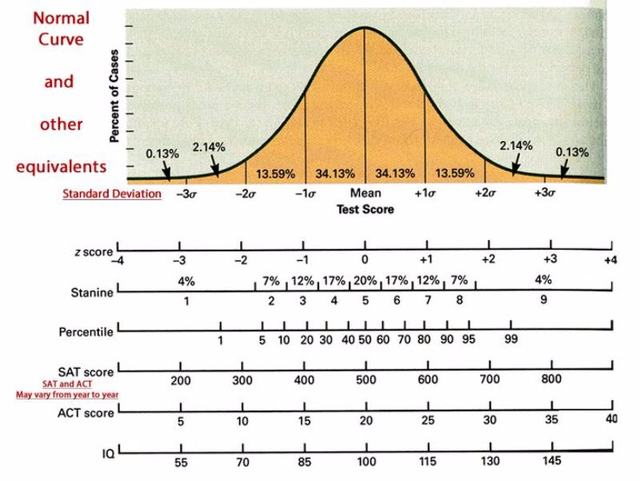

68 %: $\mu \pm \sigma$

95 %: $\mu \pm 2\sigma$

99.7 %: $\mu \pm 3\sigma$

99.997 %: $\mu \pm 4\sigma$

## Sampling distribution

**Sampling Distribution*:**

*the distribution* of *all possible values* of *a statistic* for *a given sample size*

This is the most important definition in this module. It is the boundary line between people who understand statistics and people who don’t.

Key words:

1. A given sample size
2. A statistic
3. All possible values
4. A distribution

Revisit the definitions we learnt in Week 2:

**Sample:**

a subset of the population

**Statistic:**

measures of the sample, denoted by Roman letters (e.g., $\bar x$ for the sample mean)

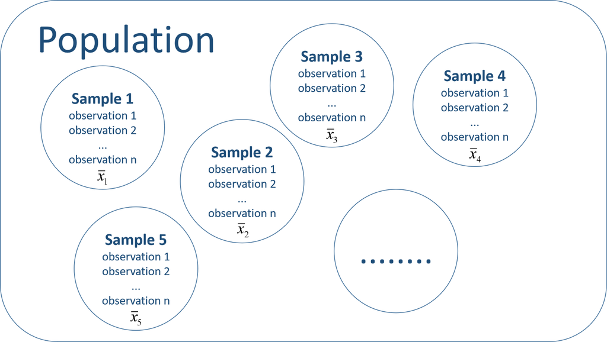

Demo: 3 out of 10.

Sample 3 observations from a population of the integers 1, 2, 3, 4, 5, 6, 7, 8, 9, 10.

```r
population <- 1:10
sample_size <- 3
choose(10, 3)
```

```
## [1] 120
```

```r
samples <- data.frame(t(combn(population, sample_size)))
samples$sample_mean <- apply(samples, 1, mean)
samples$Sample <- rownames(samples)
```

4. A distribution: a histogram for the sample mean $\bar x$.

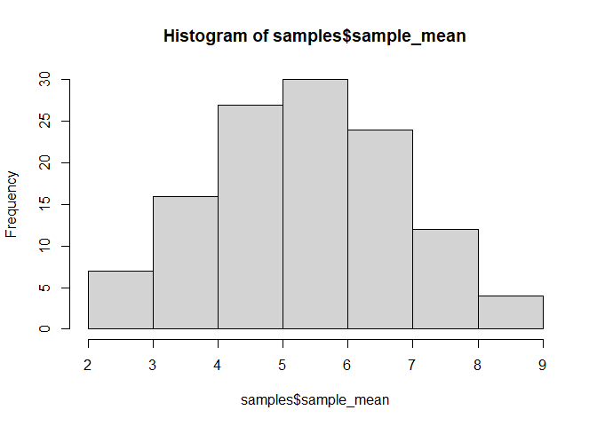

Demo: ENV203 Students’ weights

Sample 3 observations from a population of ENV203 Students’ weights.

```r
env203 <- read.csv("data/students203.csv")
w <- env203$Weight[!is.na(env203$Weight)]
length(w)
```

```
## [1] 47
```

1. A given sample size.
2. A statistic.
3. All possible values.

How many possible samples in total?

```r
choose(47, 3)
```

```
## [1] 16215
```

4. A distribution

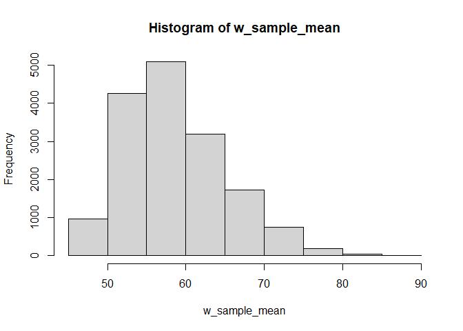

```r
w_samples <- combn(w, 3)
w_sample_mean <- apply(w_samples, 2, mean)
hist(w_sample_mean)
```

Demo: 30 out of 999.

Sample 30 observations from a population of the integers 1, 2, …, 999.

1. A given sample size.
2. A statistic: the sample mean.
3. All possible values.

```r
population <- 1:999
sample_size <- 30
choose(999, 30)
```

```
## [1] 2.35672e+57
```

It is a HUGE number.

4. A distribution

It is impossible for my computer to list all the possible samples and calculate the mean of each sample and check the distribution. How could we handle this? How could we make a sample distribution for such a case?

## Approximation of the sample distribution

We cannot list all possible samples. Instead, we randomly sample many many many times.

```r
sample1 <- sample(population, 30)
sample2 <- sample(population, 30)
```

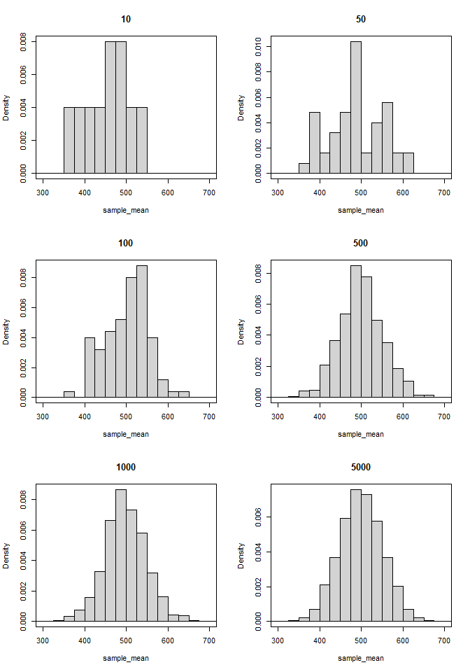

```r
par(mfrow = c(3,2))

for (rep_n in c(10, 50, 100, 500, 1000, 5000)){
  samplen <- replicate(rep_n, sample(population, sample_size))
  sample_mean <- apply(samplen, 2, mean)
  hist(sample_mean, breaks = seq(0, 1000, 25), main = rep_n,
       xlim = c(300, 700), freq = FALSE)
  box()
}
```

The distributions do not differ much when we repeat it for more than 100 times. Thus, we use one of them (500) as an approximation of the sample distribution.

## Central Limit Theorem

Let’s take a look at the approximate sample distribution.

```r
population <- 1:999
sample_size <- 30
rep_n <- 500

samplen <- replicate(rep_n, sample(population, sample_size))
sample_mean <- apply(samplen, 2, mean)
```

The mean of the sample mean ($\bar x$), which is written as $\mu _{\bar x}$, is:

```r
mean(sample_mean)
```

```
## [1] 500.3831
```

If we compare it with the population mean $\mu$:

```r
mean(population)
```

```
## [1] 500
```

Very close.

The standard deviation of the sample mean ($\bar x$), which is called the standard error ($\sigma_{\bar x}$), is:

```r
sd(sample_mean) * sqrt((rep_n - 1) / rep_n)
```

```
## [1] 52.74405
```

If we compare it with the population standard deviation $\sigma$:

```r
(st <- sd(population) * sqrt((99 - 1) / 99))
```

```
## [1] 287.0698
```

```r
st / sqrt(sample_size)
```

```
## [1] 52.41154
```

Also close.

**Central Limit Theorem:**

If $X_{1}, X_{2}, \ldots, X_{n}$ are random samples each of size $n$ taken from a population with overall mean $\mu$ and finite variance $\sigma^{2}$ and if $\bar{X}$ is the sample mean, the limiting form of the distribution of $Z=\left(\frac{\bar{X}_{n}-\mu}{\sigma / \sqrt{n}}\right)$ as $n \rightarrow \infty,$ is the standard normal distribution.

Key points:

1. The sample distribution of the mean is approximately a normal distribution if the sample size is large enough ($n \ge$ 30).
2. The mean of the sampling distribution of the mean equals to the population mean ($\mu_{\bar x} = \mu$).
3. The standard deviation of the sampling distribution of the mean, i.e. the standard error of the mean, equals to the population standard deviation divided by the square root of the sample size ($\sigma _{\bar x} = \frac{\sigma}{\sqrt N}$)

## The power of CLT

[figure not shown]

The population that supplies the samples doesn’t have to be a normal distribution for the CLT to hold.

If the population is not a normal distribution, the CLT holds if the sample size is large enough.

Demo: 30 out of 999.

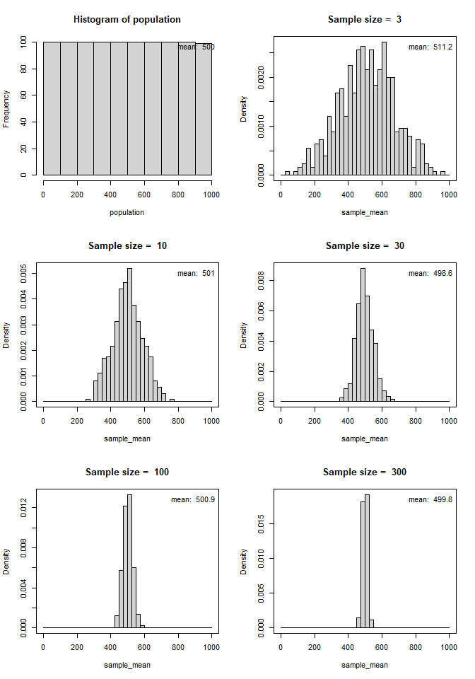

```r
population <- 1:999
rep_n <- 500
par(mfrow = c(3, 2))
hist(population)
legend("topright",
       legend = paste("mean: ", mean(population)), bty = "n")
for (sample_size in c(3, 10, 30, 100, 300)){
  samplen <- replicate(rep_n, sample(population, sample_size))
  sample_mean <- apply(samplen, 2, mean)
  hist(sample_mean, breaks = seq(0, 1000, 25),
       main = paste("Sample size = ", sample_size),
       xlim = c(0, 1000), freq = FALSE)
  legend("topright", bty = "n",
         legend = paste("mean: ", round(mean(sample_mean), 1)))
  box()
}
```

If the population is a normal distribution, the sampling distribution of the mean is a normal distribution, regardless of the sample size.

Demo: CO$_2$ concentration.

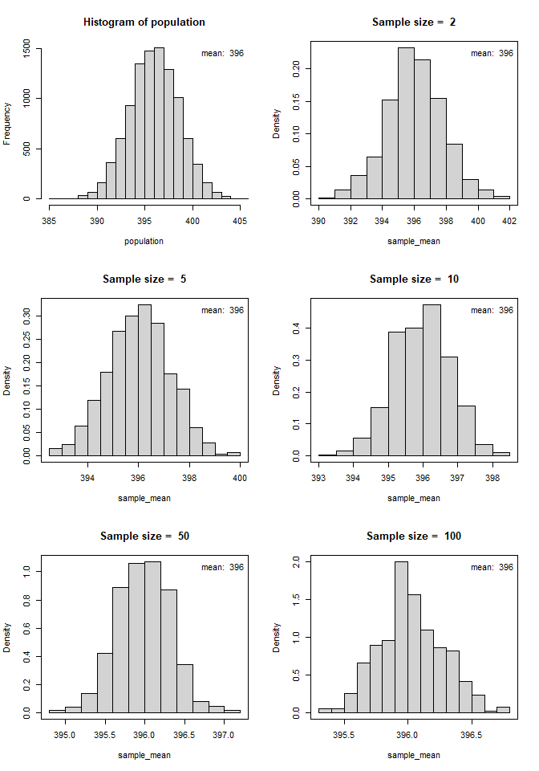

```r
li7500 <- read.csv("data/li7500.csv")
population <- li7500[, 1]
rep_n <- 500
par(mfrow = c(3, 2))
hist(population, xlim = c(385, 405))
legend("topright", bty = "n",
       legend = paste("mean: ", round(mean(population), 1)))
for (sample_size in c(2, 5, 10, 50, 100)){
  samplen <- replicate(rep_n, sample(population, sample_size))
  sample_mean <- apply(samplen, 2, mean)
  hist(sample_mean,
       main = paste("Sample size = ", sample_size), freq = FALSE)
  legend("topright", bty = "n",
         legend = paste("mean: ", round(mean(sample_mean), 1)))
  box()
}
```

## Confidence interval for a mean

- We do not know, in most times, the population parameters such as $\mu$ and $\sigma$.
- Usually we only has one sample with several observations.
- We can use the sample mean $\bar x$ as the best estimate of $\mu$, and
- the sample standard deviation $s$ as the best estimate of $\sigma$ ($\sigma = s$).

According to the CLT, the sampling distribution follows a normal distribution with the mean of $\mu _{\bar x}$ and the standard deviation of $\sigma _ {\bar x} = \frac{s}{\sqrt{n}}$. Thus, according to the features of the normal distribution, we are 95 % confident that the population mean $\mu$ is between $\bar x - 2\sigma _{\bar x}$ and $\bar x + 2\sigma _{\bar x}$.

$CI_{\alpha = 0.05}=\bar x \pm 2\sigma _{\bar x}$

What does it exactly mean? If you repeat the sampling and estimation procedure many many times, the confidence intervals you calculate would include $\mu$ 95 % of the time.

Demo: 30 out of 999.

Sample 30 observations from a population of the integers 1, 2, …, 999.

```r
population <- 1:999
mu <- mean(population)
sample_size <- 30
rep_n <- 100

samplen <- replicate(rep_n, sample(population, sample_size))
df <- data.frame(
  sample_mean = apply(samplen, 2, mean),
  standard_error = apply(samplen, 2,
                         function(x) sd(x)/sqrt(sample_size))
)
df$lower <- df$sample_mean - 2 * df$standard_error
df$upper <- df$sample_mean + 2 * df$standard_error
df$include <- mu > df$lower & mu < df$upper
sum(df$include) / rep_n
```

```
## [1] 0.96
```

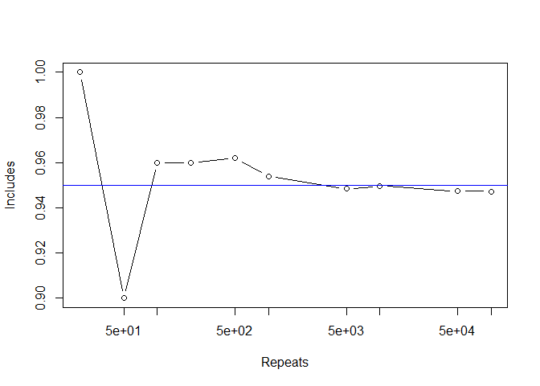

Demo: CO$_2$ concentration.

```r
li7500 <- read.csv("data/li7500.csv")
population <- li7500[, 1]

mu <- mean(population)
sample_size <- 30
rep_n <- 100

samplen <- replicate(rep_n, sample(population, sample_size))
df <- data.frame(
  sample_mean = apply(samplen, 2, mean),
  standard_error = apply(samplen, 2,
                         function(x) sd(x)/sqrt(sample_size))
)
df$lower <- df$sample_mean - 2 * df$standard_error
df$upper <- df$sample_mean + 2 * df$standard_error
df$include <- mu > df$lower & mu < df$upper
sum(df$include) / rep_n
```

```
## [1] 0.96
```

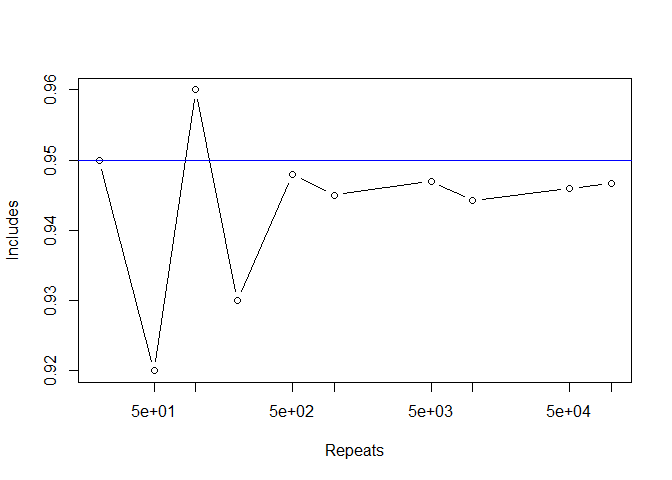

## Assignments

- Read: Sampling Distribution in R
- Read: Sampling Distribution in Excel
- Read: CLT in Excel
- Read: Control Charts and the Central Limit Theorem.pdf

## Exercises

**Experimental pond**

In an experimental pond, there are three species of fish, named as A, B, and C, with the quantitiy of 1000 for each. The lengthes of them are 1 cm, 2 cm, and 3 cm, respectively. Each fish has the equal oppotunity to be taken in a random sample.

1. What is the distribution of all the fishes’ length as the population?
- Plot a histogram.
- Give the population mean and standard deviation for the length.
2. Imagine that you randomly select a sample of 3 fishes from the population and you record the lengths of them (e.g. 1 cm, 1 cm, 3 cm) and calculate the mean (e.g. 5/3 = 1.67 cm).
- How many possible samples could you get?
- List all possible samples (e.g. 1, 1, 1; 1, 1, 2; 1, 1, 3;…) in a table.
- Show the sample distribution of the mean in a table and in a histogram.
- Calculate the standard error of the mean according to the population mean and sample size. Does it equal to the standard deviation of the sample distribution of the mean?
3. What is the probability of sampling 3 fishes with a mean length > 1.67 cm?
4. Imagine that you randomly select a sample of 30 fishes from the population and you record the lengths of them and calculate the mean.
- How many possible samples could you get?
- Show the (approximate) sample distribution of the mean in a histogram.
- Calculate the standard error of the mean according to the population mean and sample size. Does it equal to the standard deviation of the sample distribution of the mean?
5. What is the probability of sampling 30 fishes with a mean length > 1.67 cm?

**Battery life**

A manufacturer develops a new battery and wants to know how long each battery lasts averagely before it burns out. They test a sample of 30 batteries and find that the sample mean is 90 hours with a standard deviation of 25 hours.

1. Estimate the standard error of the mean.
2. Estimate the population mean and the 95 % percent confidence limits for the mean.
3. Estimate the 99 % percent confidence limits for the mean.

**Two peaks**

Download the data file twopeaks.csv from the Learning Mall. We assume it is the population of a certain environmental variable.

1. Plot a histogram of this viariable. Is it a normal distribution? why?
2. Imagine that you randomly select a sample from the population.
- If the sample size is 3, how many possible samples could you get? Show the (approximate) sample distribution of the mean in a histogram. Is it a normal distribution? Why?
- What if the sample size is 5, 10, 20, 30, 40, 50, 100, or 200? Show the (approximate) sample distribution of the mean in a histogram for each sample size. Which of them are normal distributions? Why?